# Background

The [hotel booking demand](https://www.kaggle.com/datasets/jessemostipak/hotel-booking-demand) dataset contains the booking information for City Hotel and Resort Hotel from 2015 to 2017, including number of bookings and cancellations, bookings per month, guests info includes guests type, number of adults, children, and/or babies etc.

- Keywords

Exploratory data analysis, random forest, XGBoost, logistic regression

# Exploratory data analysis

```python
import numpy as np
import pandas as pd
import matplotlib.pyplot as plt
import seaborn as sns
import warnings
warnings.filterwarnings('ignore')
%matplotlib inline
```

```python
df = pd.read_csv('./hotel_bookings.csv')
df.head()
```

|  | hotel | is_canceled | lead_time | arrival_date_year | arrival_date_month | arrival_date_week_number | arrival_date_day_of_month | stays_in_weekend_nights | stays_in_week_nights | adults | ... | deposit_type | agent | company | days_in_waiting_list | customer_type | adr | required_car_parking_spaces | total_of_special_requests | reservation_status | reservation_status_date |
| --- | --- | --- | --- | --- | --- | --- | --- | --- | --- | --- | --- | --- | --- | --- | --- | --- | --- | --- | --- | --- | --- |
| 0 | Resort Hotel | 0 | 342 | 2015 | July | 27 | 1 | 0 | 0 | 2 | ... | No Deposit | NaN | NaN | 0 | Transient | 0.0 | 0 | 0 | Check-Out | 2015-07-01 |
| 1 | Resort Hotel | 0 | 737 | 2015 | July | 27 | 1 | 0 | 0 | 2 | ... | No Deposit | NaN | NaN | 0 | Transient | 0.0 | 0 | 0 | Check-Out | 2015-07-01 |
| 2 | Resort Hotel | 0 | 7 | 2015 | July | 27 | 1 | 0 | 1 | 1 | ... | No Deposit | NaN | NaN | 0 | Transient | 75.0 | 0 | 0 | Check-Out | 2015-07-02 |
| 3 | Resort Hotel | 0 | 13 | 2015 | July | 27 | 1 | 0 | 1 | 1 | ... | No Deposit | 304.0 | NaN | 0 | Transient | 75.0 | 0 | 0 | Check-Out | 2015-07-02 |
| 4 | Resort Hotel | 0 | 14 | 2015 | July | 27 | 1 | 0 | 2 | 2 | ... | No Deposit | 240.0 | NaN | 0 | Transient | 98.0 | 0 | 1 | Check-Out | 2015-07-03 |

5 rows × 32 columns

```python
# check null values percentage
df.isnull().mean()
```

```
hotel                             0.000000
is_canceled                       0.000000
lead_time                         0.000000
arrival_date_year                 0.000000
arrival_date_month                0.000000
arrival_date_week_number          0.000000
arrival_date_day_of_month         0.000000
stays_in_weekend_nights           0.000000
stays_in_week_nights              0.000000
adults                            0.000000
children                          0.000034
babies                            0.000000
meal                              0.000000
country                           0.004087
market_segment                    0.000000
distribution_channel              0.000000
is_repeated_guest                 0.000000
previous_cancellations            0.000000
previous_bookings_not_canceled    0.000000
reserved_room_type                0.000000
assigned_room_type                0.000000
booking_changes                   0.000000
deposit_type                      0.000000
agent                             0.136862
company                           0.943069
days_in_waiting_list              0.000000
customer_type                     0.000000
adr                               0.000000
required_car_parking_spaces       0.000000
total_of_special_requests         0.000000
reservation_status                0.000000
reservation_status_date           0.000000
dtype: float64
```

```python
df.info()
```

```
<class 'pandas.core.frame.DataFrame'>
RangeIndex: 119390 entries, 0 to 119389
Data columns (total 32 columns):
 #   Column                          Non-Null Count   Dtype
---  ------                          --------------   -----
 0   hotel                           119390 non-null  object
 1   is_canceled                     119390 non-null  int64
 2   lead_time                       119390 non-null  int64
 3   arrival_date_year               119390 non-null  int64
 4   arrival_date_month              119390 non-null  object
 5   arrival_date_week_number        119390 non-null  int64
 6   arrival_date_day_of_month       119390 non-null  int64
 7   stays_in_weekend_nights         119390 non-null  int64
 8   stays_in_week_nights            119390 non-null  int64
 9   adults                          119390 non-null  int64
```

[output cut: 24 more lines]

```python
df.describe([0.01,0.05,0.1,0.25,0.5,0.75,0.99]).T
```

|  | count | mean | std | min | 1% | 5% | 10% | 25% | 50% | 75% | 99% | max |
| --- | --- | --- | --- | --- | --- | --- | --- | --- | --- | --- | --- | --- |
| is_canceled | 119390.0 | 0.370416 | 0.482918 | 0.00 | 0.0 | 0.0 | 0.0 | 0.00 | 0.000 | 1.0 | 1.00 | 1.0 |
| lead_time | 119390.0 | 104.011416 | 106.863097 | 0.00 | 0.0 | 0.0 | 3.0 | 18.00 | 69.000 | 160.0 | 444.00 | 737.0 |
| arrival_date_year | 119390.0 | 2016.156554 | 0.707476 | 2015.00 | 2015.0 | 2015.0 | 2015.0 | 2016.00 | 2016.000 | 2017.0 | 2017.00 | 2017.0 |
| arrival_date_week_number | 119390.0 | 27.165173 | 13.605138 | 1.00 | 2.0 | 5.0 | 8.0 | 16.00 | 28.000 | 38.0 | 53.00 | 53.0 |
| arrival_date_day_of_month | 119390.0 | 15.798241 | 8.780829 | 1.00 | 1.0 | 2.0 | 4.0 | 8.00 | 16.000 | 23.0 | 31.00 | 31.0 |
| stays_in_weekend_nights | 119390.0 | 0.927599 | 0.998613 | 0.00 | 0.0 | 0.0 | 0.0 | 0.00 | 1.000 | 2.0 | 4.00 | 19.0 |
| stays_in_week_nights | 119390.0 | 2.500302 | 1.908286 | 0.00 | 0.0 | 0.0 | 1.0 | 1.00 | 2.000 | 3.0 | 10.00 | 50.0 |
| adults | 119390.0 | 1.856403 | 0.579261 | 0.00 | 1.0 | 1.0 | 1.0 | 2.00 | 2.000 | 2.0 | 3.00 | 55.0 |
| children | 119386.0 | 0.103890 | 0.398561 | 0.00 | 0.0 | 0.0 | 0.0 | 0.00 | 0.000 | 0.0 | 2.00 | 10.0 |
| babies | 119390.0 | 0.007949 | 0.097436 | 0.00 | 0.0 | 0.0 | 0.0 | 0.00 | 0.000 | 0.0 | 0.00 | 10.0 |
| is_repeated_guest | 119390.0 | 0.031912 | 0.175767 | 0.00 | 0.0 | 0.0 | 0.0 | 0.00 | 0.000 | 0.0 | 1.00 | 1.0 |
| previous_cancellations | 119390.0 | 0.087118 | 0.844336 | 0.00 | 0.0 | 0.0 | 0.0 | 0.00 | 0.000 | 0.0 | 1.00 | 26.0 |
| previous_bookings_not_canceled | 119390.0 | 0.137097 | 1.497437 | 0.00 | 0.0 | 0.0 | 0.0 | 0.00 | 0.000 | 0.0 | 3.00 | 72.0 |
| booking_changes | 119390.0 | 0.221124 | 0.652306 | 0.00 | 0.0 | 0.0 | 0.0 | 0.00 | 0.000 | 0.0 | 3.00 | 21.0 |
| agent | 103050.0 | 86.693382 | 110.774548 | 1.00 | 1.0 | 1.0 | 6.0 | 9.00 | 14.000 | 229.0 | 390.00 | 535.0 |
| company | 6797.0 | 189.266735 | 131.655015 | 6.00 | 16.0 | 40.0 | 40.0 | 62.00 | 179.000 | 270.0 | 513.04 | 543.0 |
| days_in_waiting_list | 119390.0 | 2.321149 | 17.594721 | 0.00 | 0.0 | 0.0 | 0.0 | 0.00 | 0.000 | 0.0 | 75.00 | 391.0 |
| adr | 119390.0 | 101.831122 | 50.535790 | -6.38 | 0.0 | 38.4 | 50.0 | 69.29 | 94.575 | 126.0 | 252.00 | 5400.0 |
| required_car_parking_spaces | 119390.0 | 0.062518 | 0.245291 | 0.00 | 0.0 | 0.0 | 0.0 | 0.00 | 0.000 | 0.0 | 1.00 | 8.0 |
| total_of_special_requests | 119390.0 | 0.571363 | 0.792798 | 0.00 | 0.0 | 0.0 | 0.0 | 0.00 | 0.000 | 1.0 | 3.00 | 5.0 |

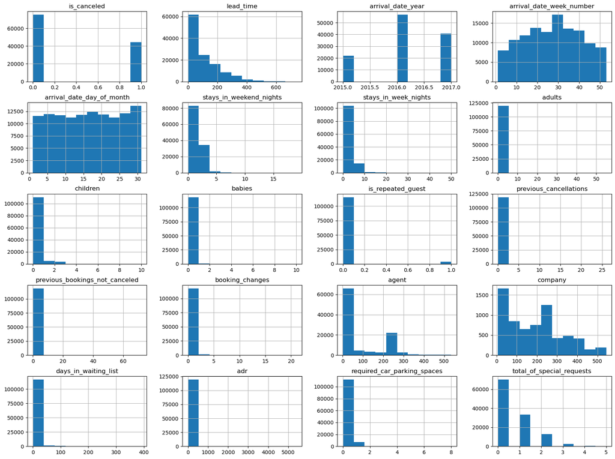

```python
df.hist(figsize=(20,15))
plt.show()
```

# Data visualization analysis

## Hotel bookings and cancellations

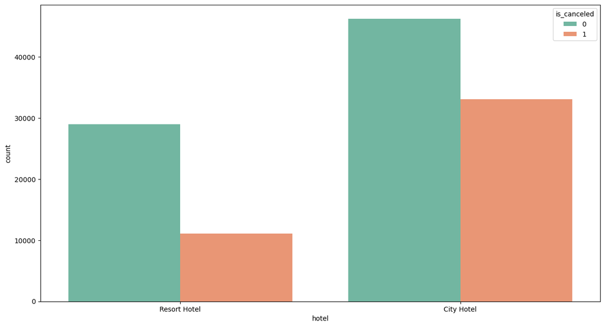

```python
plt.figure(figsize=(15,8))
sns.countplot(x='hotel'
             ,data=df
             ,hue='is_canceled'
             ,palette=sns.color_palette('Set2',2)
            )
```

```python
hotel_cancellation_num = df.loc[df['is_canceled'] == 1]['hotel'].value_counts()
hotel_num = df['hotel'].value_counts()
hotel_cancellation_ratio = (hotel_cancellation_num / hotel_num).sort_values(ascending=False)

print('Hotel Cancellation Ratio'.center(20), hotel_cancellation_ratio, sep='\n')
```

```
Hotel Cancellation Ratio
City Hotel      0.417270
Resort Hotel    0.277634
Name: hotel, dtype: float64
```

City Hotel has much higher cancellation than Resort Hotel.

## Hotel bookings per month

```python
booking_city_hotel = df[(df['hotel']=='City Hotel') & (df['is_canceled']==0)]
booking_resort_hotel = df[(df['hotel']=='Resort Hotel') & (df['is_canceled']==0)]
```

```python
booking_city_hotel['arrival_date_year_month'] = booking_city_hotel['arrival_date_year'].astype(str) + ' ' + booking_city_hotel['arrival_date_month'].str[:3]
```

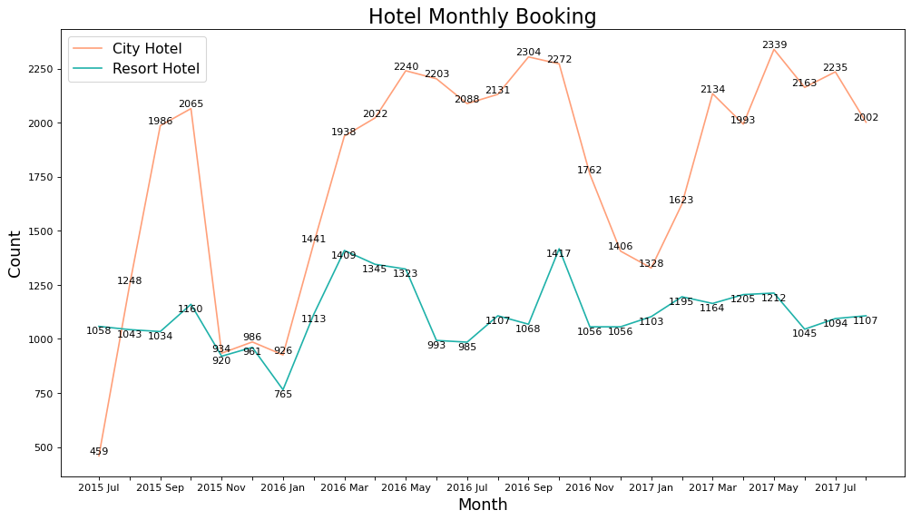

```python
booking_city_hotel['arrival_date_year_month'] = booking_city_hotel['arrival_date_year'].astype(str) + ' ' + booking_city_hotel['arrival_date_month'].str[:3]
booking_resort_hotel['arrival_date_year_month'] = booking_resort_hotel['arrival_date_year'].astype(str) + ' ' + booking_resort_hotel['arrival_date_month'].str[:3]


city_month = booking_city_hotel['arrival_date_year_month'].value_counts()
resort_month = booking_resort_hotel['arrival_date_year_month'].value_counts()

month = ['Jan','Feb','Mar','Apr','May','Jun','Jul','Aug','Sep','Oct','Nov','Dec']
year = ['2015', '2016', '2017']
month_index = [year[0]+" " +a for a in month[6:]] + [year[1]+" "+a for a in month] + [year[2]+" "+a for a in month[:8]]

city_month_new = pd.DataFrame({'month_index':month_index})
city_month_new['bookings'] = city_month_new['month_index'].map(city_month.to_dict())
resort_month_new = pd.DataFrame({'month_index':month_index})
resort_month_new['bookings'] = resort_month_new['month_index'].map(resort_month.to_dict())

name = []
for i in range(len(city_month_new.month_index)):
    if i%2 == 0:
        name.append(city_month_new.month_index[i])
    else:
        name.append('')

x = city_month_new.month_index
y1 = city_month_new.bookings
y2 = resort_month_new.bookings

plt.figure(figsize=(15,8),dpi=80)
plt.plot(x,y1,label='City Hotel',color='lightsalmon')
plt.plot(x,y2,label='Resort Hotel',color='lightseagreen')
plt.xticks(x,name,fontsize=10)
plt.legend(fontsize=14)
plt.xlabel('Month', fontsize=16)
plt.ylabel('Count', fontsize=16)
plt.title('Hotel Monthly Booking', fontsize=20)
for i,j in zip(x,y1):
    plt.text(i,j,'%d' % j,ha = 'center',va = 'bottom', fontsize=10)

for i,j in zip(x,y2):
    plt.text(i,j,'%d' % j,ha = 'center',va = 'top', fontsize=10)
```

## Guest country and cancellation ratio

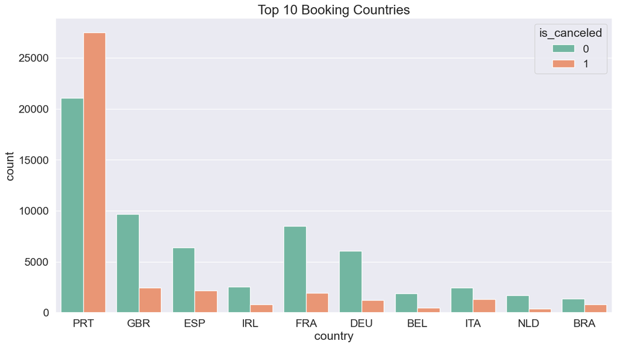

```python
country_booking = df['country'].value_counts()[:10]
country_cancellation = df[(df.country.isin (country_booking.index)) & (df.is_canceled==1)]['country'].value_counts()

plt.figure(figsize=(15,8))
sns.set(font_scale=1.5)
sns.countplot(x='country'
              ,data=df[df.country.isin (country_booking.index)]
              ,hue='is_canceled'
              ,palette=sns.color_palette('Set2',2)
             )
plt.title('Top 10 Booking Countries', fontsize=20)
```

```python
country_cancellation_ratio=(country_cancellation/country_booking).sort_values(ascending=False)
print('Cancellation Ratio by Country'.center(10),country_cancellation_ratio,sep='\n')
```

```
Cancellation Ratio by Country
PRT    0.566351
BRA    0.373201
ITA    0.353956
ESP    0.254085
IRL    0.246519
BEL    0.202391
GBR    0.202243
FRA    0.185694
NLD    0.183935
DEU    0.167147
Name: country, dtype: float64
```

## Customer types

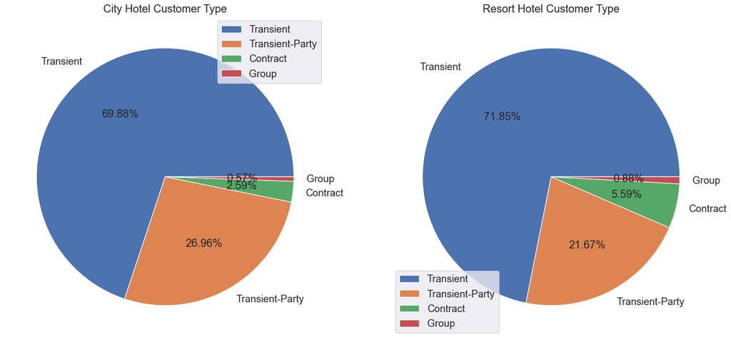

```python
city_customer = booking_city_hotel['customer_type'].value_counts()
resort_customer = booking_resort_hotel['customer_type'].value_counts()

plt.figure(figsize=(21,12),dpi=80)
plt.subplot(1,2,1)
plt.pie(city_customer,labels=city_customer.index,autopct='%.2f%%')
plt.legend(loc=1)
plt.title('City Hotel Customer Type')
plt.subplot(1,2,2)
plt.pie(resort_customer,labels=resort_customer.index,autopct='%.2f%%')
plt.title('Resort Hotel Customer Type')
plt.legend()
plt.show()
```

## Market segment

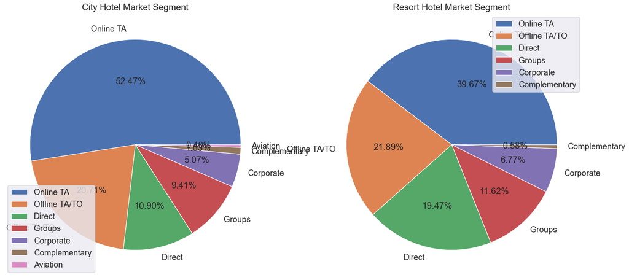

```python
city_segment = booking_city_hotel.market_segment.value_counts()
resort_segment = booking_resort_hotel.market_segment.value_counts()

plt.figure(figsize=(21,12),dpi=80)
plt.subplot(1,2,1)
plt.pie(city_segment,labels=city_segment.index,autopct='%.2f%%')
plt.legend()
plt.title('City Hotel Market Segment')
plt.subplot(1,2,2)
plt.pie(resort_segment,labels=resort_segment.index,autopct='%.2f%%')
plt.title('Resort Hotel Market Segment')
plt.legend()
plt.show()
```

## Average daily rate of different customer type

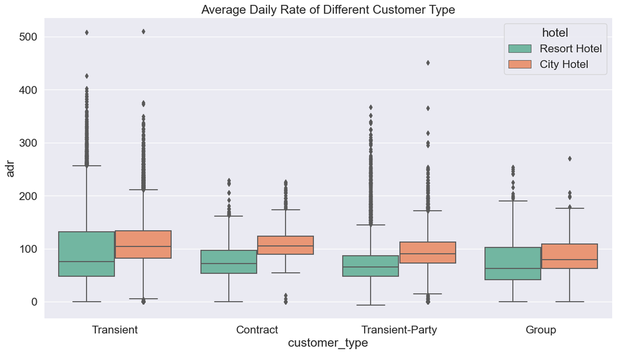

```python
plt.figure(figsize=(15,8))
sns.boxplot(x='customer_type'
            ,y='adr'
            ,hue='hotel'
            ,data=df[df.is_canceled==0]
            ,palette=sns.color_palette('Set2',2)
           )
plt.title('Average Daily Rate of Different Customer Type')
```

## New/Repeated Guest Amount

```
 [Text(0, 0, 'no'), Text(1, 0, 'yes')])
```

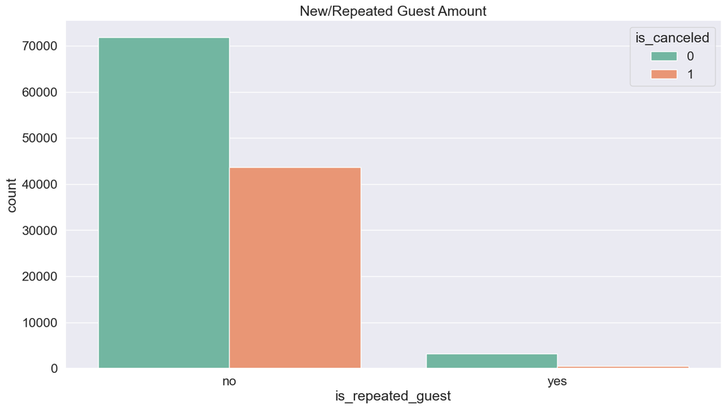

```python
plt.figure(figsize=(15,8))
sns.countplot(x='is_repeated_guest'
              ,data=df
              ,hue='is_canceled'
              ,palette=sns.color_palette('Set2',2)
             )
plt.title('New/Repeated Guest Amount')
plt.xticks(range(2),['no','yes'])
```

```python
guest_cancellation = (df.loc[df['is_canceled']==1]['is_repeated_guest'].value_counts()/df['is_repeated_guest'].value_counts()).sort_values(ascending=False)
guest_cancellation.index=['New Guest', 'Repeated Guest']
print('New/Repeated Guest Cancellation Ratio'.center(15),guest_cancellation,sep='\n')
```

```
New/Repeated Guest Cancellation Ratio
New Guest         0.377851
Repeated Guest    0.144882
Name: is_repeated_guest, dtype: float64
```

## 3 deposit types

```python
print('Deposit types and number of bookings'.center(15),df['deposit_type'].value_counts(),sep='\n')
```

```
Deposit types and number of bookings
No Deposit    104641
Non Refund     14587
Refundable       162
Name: deposit_type, dtype: int64
```

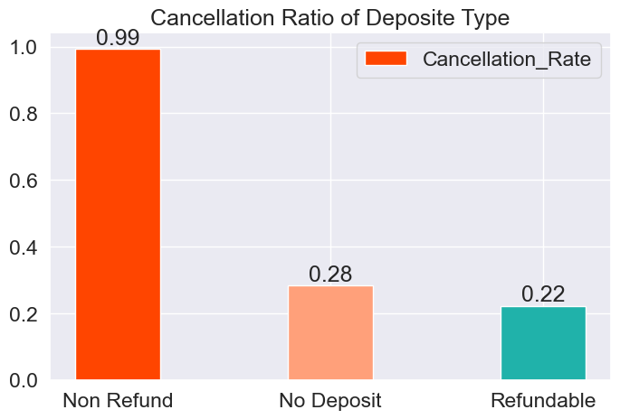

```python
deposit_cancellation = (df.loc[df['is_canceled']==1]['deposit_type'].value_counts()/df['deposit_type'].value_counts()).sort_values(ascending=False)

plt.figure(figsize=(8,5))
x=range(len(deposit_cancellation.index))
y=deposit_cancellation.values
plt.bar(x,y,label='Cancellation_Rate',color=['orangered','lightsalmon','lightseagreen'],width=0.4)
plt.xticks(x,deposit_cancellation.index)
plt.legend()
plt.title('Cancellation Ratio of Deposite Type')
for x,y in zip(x,y):
    plt.text(x,y,'%.2f' % y,ha = 'center',va = 'bottom')
```

## Room types

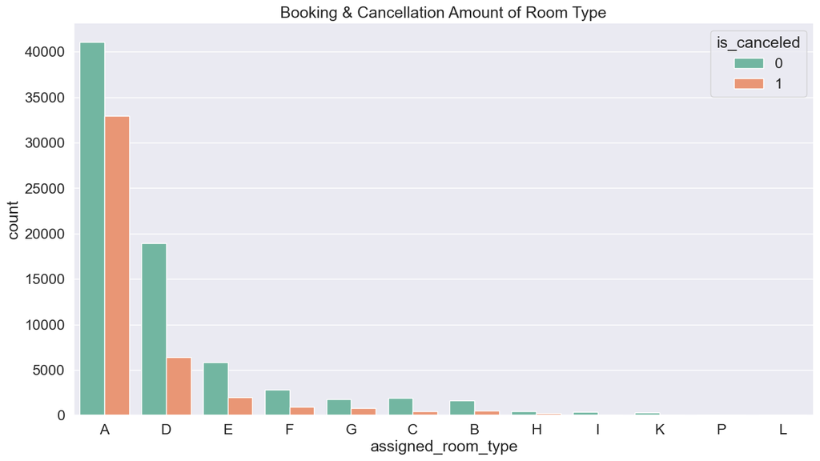

```python
plt.figure(figsize=(15,8))
sns.countplot(x='assigned_room_type'
              ,data=df
              ,hue='is_canceled'
              ,palette=sns.color_palette('Set2',2)
              ,order = df['assigned_room_type'].value_counts().index
             )
plt.title('Booking & Cancellation Amount of Room Type')
```

```python
room_cancellation = df.loc[df['is_canceled']==1]['assigned_room_type'].value_counts()[:5]/df['assigned_room_type'].value_counts()[:5]
print('Top 5 cancelled room types'.center(5),room_cancellation.sort_values(ascending=False),sep='\n')
```

```
Top 5 cancelled room types
A    0.444925
G    0.305523
E    0.252114
D    0.251244
F    0.247134
Name: assigned_room_type, dtype: float64
```

# Data Preprocessing

As it is going to predict whether guests will cancel the bookings, the column "is_canceled" would be the target label, the rest columns are the feature attributes. The attribute 'reservation_status_date' is useless for the final results, therefore we can remove it.

```python
df_new = df.drop(labels=['reservation_status_date'],axis=1)
```

## Categorical attributes

```python
df_new.dtypes
```

```
hotel                              object
is_canceled                         int64
lead_time                           int64
arrival_date_year                   int64
arrival_date_month                 object
arrival_date_week_number            int64
arrival_date_day_of_month           int64
stays_in_weekend_nights             int64
stays_in_week_nights                int64
adults                              int64
children                          float64
babies                              int64
meal                               object
country                            object
market_segment                     object
distribution_channel               object
is_repeated_guest                   int64
previous_cancellations              int64
previous_bookings_not_canceled      int64
reserved_room_type                 object
assigned_room_type                 object
booking_changes                     int64
deposit_type                       object
agent                             float64
company                           float64
days_in_waiting_list                int64
customer_type                      object
adr                               float64
required_car_parking_spaces         int64
total_of_special_requests           int64
reservation_status                 object
dtype: object
```

```python
text_categorical_cols = df_new.columns[df_new.dtypes=='object'].tolist()
numerical_categorical_cols = ['agent', 'company', 'is_repeated_guest']
categorical_cols = text_categorical_cols + numerical_categorical_cols
```

```python
df_new.isnull().mean()
```

```
hotel                             0.000000
is_canceled                       0.000000
lead_time                         0.000000
arrival_date_year                 0.000000
arrival_date_month                0.000000
arrival_date_week_number          0.000000
arrival_date_day_of_month         0.000000
stays_in_weekend_nights           0.000000
stays_in_week_nights              0.000000
adults                            0.000000
children                          0.000034
babies                            0.000000
meal                              0.000000
country                           0.004087
market_segment                    0.000000
distribution_channel              0.000000
is_repeated_guest                 0.000000
previous_cancellations            0.000000
previous_bookings_not_canceled    0.000000
reserved_room_type                0.000000
assigned_room_type                0.000000
booking_changes                   0.000000
deposit_type                      0.000000
agent                             0.136862
company                           0.943069
days_in_waiting_list              0.000000
customer_type                     0.000000
adr                               0.000000
required_car_parking_spaces       0.000000
total_of_special_requests         0.000000
reservation_status                0.000000
dtype: float64
```

```python
df_new[['agent','company']] = df_new[['agent','company']].fillna(0,axis=0)
df_new.loc[:,categorical_cols].isnull().mean()
```

```
hotel                   0.000000
arrival_date_month      0.000000
meal                    0.000000
country                 0.004087
market_segment          0.000000
distribution_channel    0.000000
reserved_room_type      0.000000
assigned_room_type      0.000000
deposit_type            0.000000
customer_type           0.000000
reservation_status      0.000000
agent                   0.000000
company                 0.000000
is_repeated_guest       0.000000
dtype: float64
```

```python
df_new.loc[df_new['company'] == 0,'in_company']='NO'
df_new.loc[df_new['company'] != 0,'in_company']='YES'
df_new.loc[df_new['agent'] == 0,'in_agent']='NO'
df_new.loc[df_new['agent'] != 0,'in_agent']='YES'
df_new['is_repeated_guest'][df_new['is_repeated_guest']==0]='NO'
df_new['is_repeated_guest'][df_new['is_repeated_guest']==1]='YES'
df_new.loc[df_new['reserved_room_type'] == df_new['assigned_room_type'],'same_assignment']='YES'
df_new.loc[df_new['reserved_room_type'] != df_new['assigned_room_type'],'same_assignment']='NO'

df_new=df_new.drop(labels=['reserved_room_type','assigned_room_type','agent','company'],axis=1)
df_new[['in_agent','in_company','is_repeated_guest','same_assignment']].head()
```

|  | in_agent | in_company | is_repeated_guest | same_assignment |
| --- | --- | --- | --- | --- |
| 0 | NO | NO | NO | YES |
| 1 | NO | NO | NO | YES |
| 2 | NO | NO | NO | NO |
| 3 | YES | NO | NO | YES |
| 4 | YES | NO | NO | YES |

```python
for c in ['in_company','in_agent','same_assignment']:
    categorical_cols.append(c)

for c in ['reserved_room_type','assigned_room_type','agent','company']:
    categorical_cols.remove(c)
categorical_cols
```

```
['hotel',
 'arrival_date_month',
 'meal',
 'country',
 'market_segment',
 'distribution_channel',
 'deposit_type',
 'customer_type',
 'reservation_status',
 'is_repeated_guest',
 'in_company',
 'in_agent',
 'same_assignment']
```

```python
# Fill ungiven 'country' attribute with the most frequent country
df_new['country']=df_new['country'].fillna(df_new['country'].mode()[0])
df_new['country'].unique()
```

```
array(['PRT', 'GBR', 'USA', 'ESP', 'IRL', 'FRA', 'ROU', 'NOR', 'OMN',
       'ARG', 'POL', 'DEU', 'BEL', 'CHE', 'CN', 'GRC', 'ITA', 'NLD',
       'DNK', 'RUS', 'SWE', 'AUS', 'EST', 'CZE', 'BRA', 'FIN', 'MOZ',
       'BWA', 'LUX', 'SVN', 'ALB', 'IND', 'CHN', 'MEX', 'MAR', 'UKR',
       'SMR', 'LVA', 'PRI', 'SRB', 'CHL', 'AUT', 'BLR', 'LTU', 'TUR',
       'ZAF', 'AGO', 'ISR', 'CYM', 'ZMB', 'CPV', 'ZWE', 'DZA', 'KOR',
       'CRI', 'HUN', 'ARE', 'TUN', 'JAM', 'HRV', 'HKG', 'IRN', 'GEO',
       'AND', 'GIB', 'URY', 'JEY', 'CAF', 'CYP', 'COL', 'GGY', 'KWT',
       'NGA', 'MDV', 'VEN', 'SVK', 'FJI', 'KAZ', 'PAK', 'IDN', 'LBN',
       'PHL', 'SEN', 'SYC', 'AZE', 'BHR', 'NZL', 'THA', 'DOM', 'MKD',
       'MYS', 'ARM', 'JPN', 'LKA', 'CUB', 'CMR', 'BIH', 'MUS', 'COM',
       'SUR', 'UGA', 'BGR', 'CIV', 'JOR', 'SYR', 'SGP', 'BDI', 'SAU',
       'VNM', 'PLW', 'QAT', 'EGY', 'PER', 'MLT', 'MWI', 'ECU', 'MDG',
       'ISL', 'UZB', 'NPL', 'BHS', 'MAC', 'TGO', 'TWN', 'DJI', 'STP',
       'KNA', 'ETH', 'IRQ', 'HND', 'RWA', 'KHM', 'MCO', 'BGD', 'IMN',
       'TJK', 'NIC', 'BEN', 'VGB', 'TZA', 'GAB', 'GHA', 'TMP', 'GLP',
       'KEN', 'LIE', 'GNB', 'MNE', 'UMI', 'MYT', 'FRO', 'MMR', 'PAN',
       'BFA', 'LBY', 'MLI', 'NAM', 'BOL', 'PRY', 'BRB', 'ABW', 'AIA',
       'SLV', 'DMA', 'PYF', 'GUY', 'LCA', 'ATA', 'GTM', 'ASM', 'MRT',
       'NCL', 'KIR', 'SDN', 'ATF', 'SLE', 'LAO'], dtype=object)
```

```python
# Encode the categorical attributes

from sklearn.preprocessing import OrdinalEncoder

o_encoder = OrdinalEncoder()
df_new.loc[:,categorical_cols] = o_encoder.fit_transform(df_new.loc[:,categorical_cols])
```

## Numerical attributes

```python
numerical_cols = df_new.columns.tolist()
numerical_cols.remove('is_canceled')
for c in categorical_cols:
    numerical_cols.remove(c)

numerical_cols
```

```
['lead_time',
 'arrival_date_year',
 'arrival_date_week_number',
 'arrival_date_day_of_month',
 'stays_in_weekend_nights',
 'stays_in_week_nights',
 'adults',
 'children',
 'babies',
 'previous_cancellations',
 'previous_bookings_not_canceled',
 'booking_changes',
 'days_in_waiting_list',
 'adr',
 'required_car_parking_spaces',
 'total_of_special_requests']
```

```python
df[numerical_cols].isnull().mean()
```

```
lead_time                         0.000000
arrival_date_year                 0.000000
arrival_date_week_number          0.000000
arrival_date_day_of_month         0.000000
stays_in_weekend_nights           0.000000
stays_in_week_nights              0.000000
adults                            0.000000
children                          0.000034
babies                            0.000000
previous_cancellations            0.000000
previous_bookings_not_canceled    0.000000
booking_changes                   0.000000
days_in_waiting_list              0.000000
adr                               0.000000
required_car_parking_spaces       0.000000
total_of_special_requests         0.000000
dtype: float64
```

```python
# Fill ungiven 'children' with the most frequent value
df_new['children'] = df_new['children'].fillna(df_new['children'].mode()[0])
```

```python
# Use standard scaler to scale the numerical attributes

from sklearn.preprocessing import StandardScaler
s_scaler = StandardScaler()
df_new.loc[:,numerical_cols] = s_scaler.fit_transform(df_new.loc[:,numerical_cols])
df_new[numerical_cols].head()
```

|  | lead_time | arrival_date_year | arrival_date_week_number | arrival_date_day_of_month | stays_in_weekend_nights | stays_in_week_nights | adults | children | babies | previous_cancellations | previous_bookings_not_canceled | booking_changes | days_in_waiting_list | adr | required_car_parking_spaces | total_of_special_requests |
| --- | --- | --- | --- | --- | --- | --- | --- | --- | --- | --- | --- | --- | --- | --- | --- | --- |
| 0 | 2.227051 | -1.634768 | -0.012141 | -1.685297 | -0.92889 | -1.310240 | 0.247897 | -0.260659 | -0.081579 | -0.10318 | -0.091555 | 4.260101 | -0.131924 | -2.015038 | -0.254873 | -0.720694 |
| 1 | 5.923385 | -1.634768 | -0.012141 | -1.685297 | -0.92889 | -1.310240 | 0.247897 | -0.260659 | -0.081579 | -0.10318 | -0.091555 | 5.793131 | -0.131924 | -2.015038 | -0.254873 | -0.720694 |
| 2 | -0.907814 | -1.634768 | -0.012141 | -1.685297 | -0.92889 | -0.786207 | -1.478447 | -0.260659 | -0.081579 | -0.10318 | -0.091555 | -0.338990 | -0.131924 | -0.530935 | -0.254873 | -0.720694 |
| 3 | -0.851667 | -1.634768 | -0.012141 | -1.685297 | -0.92889 | -0.786207 | -1.478447 | -0.260659 | -0.081579 | -0.10318 | -0.091555 | -0.338990 | -0.131924 | -0.530935 | -0.254873 | -0.720694 |
| 4 | -0.842309 | -1.634768 | -0.012141 | -1.685297 | -0.92889 | -0.262174 | 0.247897 | -0.260659 | -0.081579 | -0.10318 | -0.091555 | -0.338990 | -0.131924 | -0.075810 | -0.254873 | 0.540666 |

## Attributes correlation

```python
corr_matrix = df_new.corr()
corr_matrix['is_canceled'].sort_values(ascending=False)
```

```
is_canceled                       1.000000
deposit_type                      0.468634
lead_time                         0.293123
country                           0.267502
same_assignment                   0.247770
distribution_channel              0.167600
previous_cancellations            0.110133
in_agent                          0.102068
adults                            0.060017
market_segment                    0.059338
days_in_waiting_list              0.054186
adr                               0.047557
stays_in_week_nights              0.024765
arrival_date_year                 0.016660
arrival_date_week_number          0.008148
children                          0.005036
arrival_date_month               -0.001491
stays_in_weekend_nights          -0.001791
arrival_date_day_of_month        -0.006130
meal                             -0.017678
babies                           -0.032491
previous_bookings_not_canceled   -0.057358
customer_type                    -0.068140
is_repeated_guest                -0.084793
in_company                       -0.099310
hotel                            -0.136531
booking_changes                  -0.144381
required_car_parking_spaces      -0.195498
total_of_special_requests        -0.234658
reservation_status               -0.917196
Name: is_canceled, dtype: float64
```

```python
corr_matrix.index
```

```
Index(['hotel', 'is_canceled', 'lead_time', 'arrival_date_year',
       'arrival_date_month', 'arrival_date_week_number',
       'arrival_date_day_of_month', 'stays_in_weekend_nights',
       'stays_in_week_nights', 'adults', 'children', 'babies', 'meal',
       'country', 'market_segment', 'distribution_channel',
       'is_repeated_guest', 'previous_cancellations',
       'previous_bookings_not_canceled', 'booking_changes', 'deposit_type',
       'days_in_waiting_list', 'customer_type', 'adr',
       'required_car_parking_spaces', 'total_of_special_requests',
       'reservation_status', 'in_company', 'in_agent', 'same_assignment'],
      dtype='object')
```

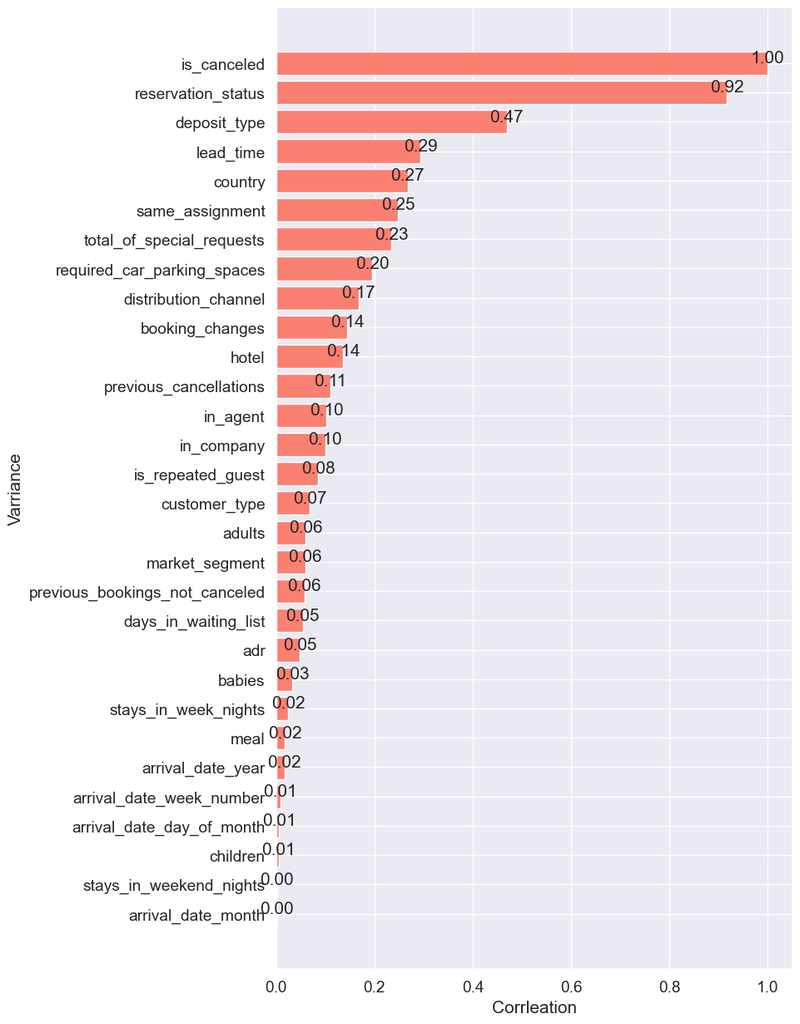

```python
corr_cancel=abs(corr_matrix['is_canceled']).sort_values()
x=range(len(corr_cancel.index))
y=abs(corr_cancel.values)

sns.set(font_scale=1.25)
plt.figure(figsize=(8,15))
plt.barh(x,y,color='salmon')
plt.yticks(x,corr_cancel.index)
for x,y in zip(x,y):
    plt.text(y,x-0.1,'%.2f' % y,ha = 'center',va = 'bottom')
plt.xlabel('Corrleation')
plt.ylabel('Varriance')
plt.show()
```

'reservation_status' has the highest correlation with the target 'is_canceled', in order to avoid overfitting, it is better to drop the attribute 'reservation_status'.

```python
df_cleaned = df_new.drop('reservation_status',axis=1)
```

# Prediction models

```python
x=df_cleaned.loc[:,df_cleaned.columns != 'is_canceled' ]
y=df_cleaned.loc[:,'is_canceled']

from sklearn.model_selection import train_test_split
xtrain,xtest,ytrain,ytest=train_test_split(x,y,test_size=0.2,random_state=90)
```

## Random forest

```python
from sklearn.ensemble import RandomForestClassifier
from sklearn.model_selection import cross_val_score as cvs,KFold
from sklearn.metrics import accuracy_score
from sklearn.metrics import roc_curve
from sklearn.metrics import roc_auc_score as AUC

rfc = RandomForestClassifier(n_estimators=100,random_state=90)
cv = KFold(n_splits=10, shuffle = True, random_state=90)
rfc_score = cvs(rfc,xtrain,ytrain,cv=cv).mean()
rfc.fit(xtrain,ytrain)
y_score=rfc.predict_proba(xtest)[:,1]
rfc_pred=rfc.predict(xtest)

fpr, recall, thresholds = roc_curve(ytest,y_score, pos_label=1)
rfc_auc = AUC(ytest,y_score)
```

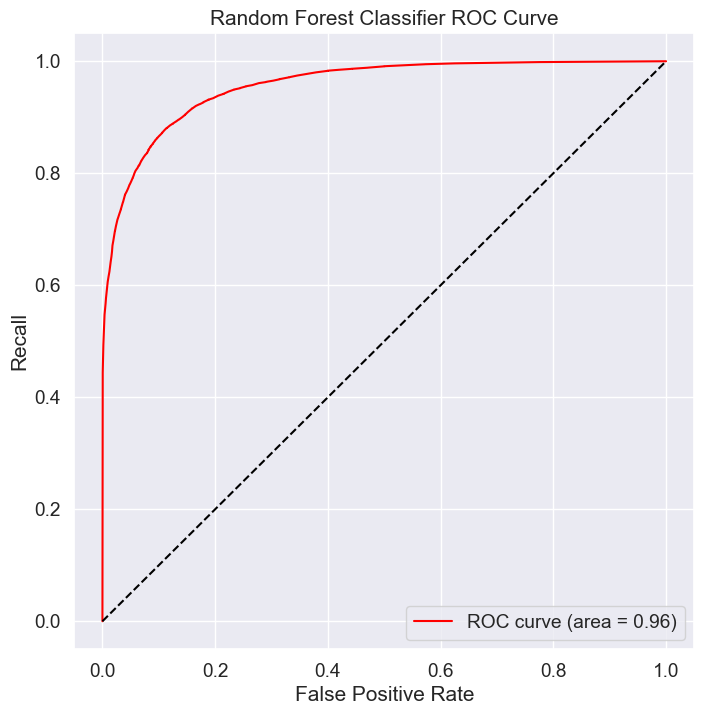

```python
plt.figure(figsize=(8,8))
plt.plot(fpr, recall, color='red',label='ROC curve (area = %0.2f)' % rfc_auc)
plt.plot([0, 1], [0, 1], color='black', linestyle='--')
plt.xlim([-0.05, 1.05])
plt.ylim([-0.05, 1.05])
plt.xlabel('False Positive Rate')
plt.ylabel('Recall')
plt.title('Random Forest Classifier ROC Curve')
plt.legend(loc="lower right")
plt.show()
```

## XGBoost

```python
from xgboost import XGBClassifier

xgbr = XGBClassifier(n_estimators=100,random_state=90)
xgbr_score = cvs(xgbr,xtrain,ytrain,cv=cv).mean()
xgbr.fit(xtrain,ytrain)
y_score = xgbr.predict_proba(xtest)[:,1]
xgbr_pred = xgbr.predict(xtest)
fdr, recall, thresholds = roc_curve(ytest,y_score, pos_label=1)
xgbr_auc = AUC(ytest,y_score)
```

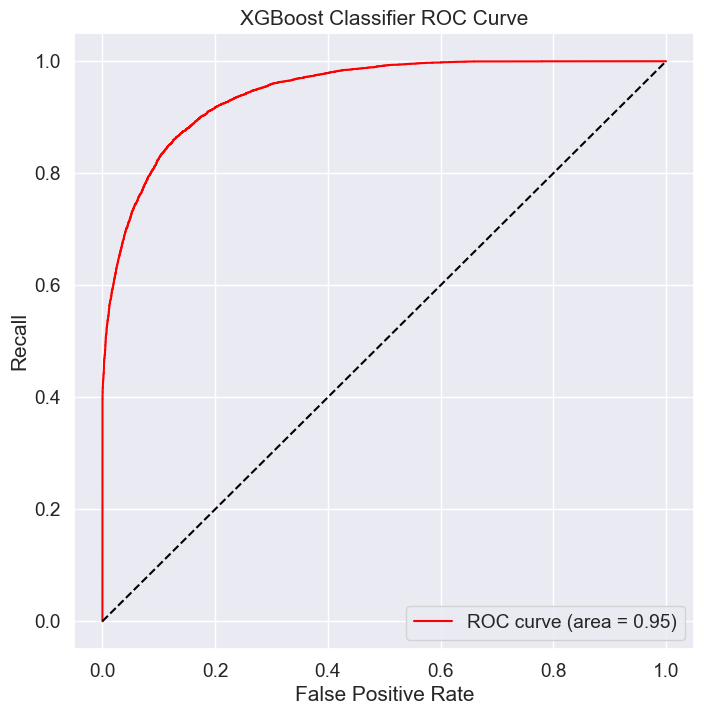

```python
plt.figure(figsize=(8,8))
plt.plot(fdr, recall, color='red',label='ROC curve (area = %0.2f)' % xgbr_auc)
plt.plot([0, 1], [0, 1], color='black', linestyle='--')
plt.xlim([-0.05, 1.05])
plt.ylim([-0.05, 1.05])
plt.xlabel('False Positive Rate')
plt.ylabel('Recall')
plt.title('XGBoost Classifier ROC Curve')
plt.legend(loc="lower right")
plt.show()
```

## Logistic regression

```python
from sklearn.linear_model import LogisticRegression as LR
lr = LR(penalty='l2',solver='liblinear',max_iter=1000)
lr_score = cvs(lr,xtrain,ytrain,cv=cv).mean()
lr.fit(xtrain,ytrain)
y_score = lr.predict_proba(xtest)[:,1]
lr_pred = lr.predict(xtest)
fdr, recall, thresholds = roc_curve(ytest,y_score, pos_label=1)
lr_auc = AUC(ytest,y_score)
```

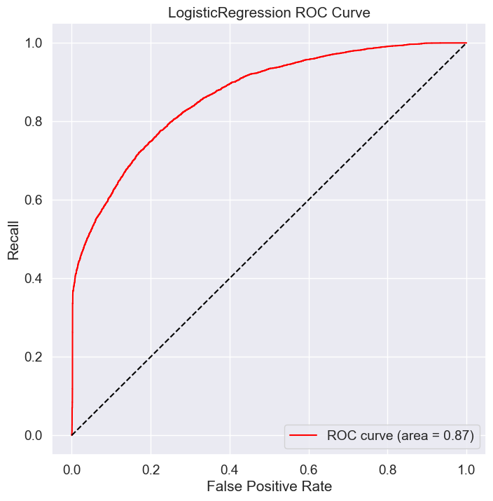

```python
plt.figure(figsize=(8,8))
plt.plot(fdr, recall, color='red',label='ROC curve (area = %0.2f)' % lr_auc)
plt.plot([0, 1], [0, 1], color='black', linestyle='--')
plt.xlim([-0.05, 1.05])
plt.ylim([-0.05, 1.05])
plt.xlabel('False Positive Rate')
plt.ylabel('Recall')
plt.title('LogisticRegression ROC Curve')
plt.legend(loc="lower right")
plt.show()
```

## Model performance comparison

```python
from sklearn.metrics import classification_report
print('Random forest'.center(50), classification_report(ytest,rfc_pred),sep='\n')
print('XGBoost'.center(55),classification_report(ytest,xgbr_pred),sep='\n')
print('Logistic regression'.center(50),classification_report(ytest,lr_pred),sep='\n')
```

```
                  Random forest
              precision    recall  f1-score   support

           0       0.90      0.93      0.92     15153
           1       0.87      0.82      0.85      8725

    accuracy                           0.89     23878
   macro avg       0.89      0.88      0.88     23878
weighted avg       0.89      0.89      0.89     23878

                        XGBoost
              precision    recall  f1-score   support

           0       0.89      0.91      0.90     15153
           1       0.84      0.80      0.82      8725

    accuracy                           0.87     23878
   macro avg       0.87      0.86      0.86     23878
weighted avg       0.87      0.87      0.87     23878

               Logistic regression
              precision    recall  f1-score   support

           0       0.80      0.91      0.85     15153
           1       0.79      0.60      0.68      8725

    accuracy                           0.80     23878
   macro avg       0.79      0.75      0.76     23878
weighted avg       0.80      0.80      0.79     23878
```

```python
score={'Model_score':[rfc_score,xgbr_score,lr_score],'Auc_area':[rfc_auc,xgbr_auc,lr_auc]}
score_com=pd.DataFrame(data=score,index=['RandomForest','XGBoost','LogisticRegression'])
score_com.sort_values(by=['Model_score'],ascending=False)
```

|  | Model_score | Auc_area |
| --- | --- | --- |
| RandomForest | 0.889982 | 0.956306 |
| XGBoost | 0.873576 | 0.946361 |
| LogisticRegression | 0.796476 | 0.866788 |